# Probability theory - HW 2, task 4

Анастасия Горшкова

2024-10-13

## Скрипт для анализа влияния объема выборки и истинной вероятности на ошибку

# Для бинарной величины

На лекции мы работали со скриптом, в котором мы производили оценку математического ожидания случайной величины (прироста гемоглобина). Теперь мы хотим провести виртуальный эксперимент, в котором мы будем оценивать вероятность некого события (например полного исцеления после приема терапии). По-прежнему, дизайн одногрупповой. Переделайте скрипт так, чтобы в нем можно было бы анализировать ошибку в оценке вероятности события в зависимости от истинной вероятности и объема выборки. Какие закономерности вы можете вычислить, экспериментируя со скриптом? Скрипт необходимо загрузить в гитхаб и дать на него ссылку в гугл-классе.

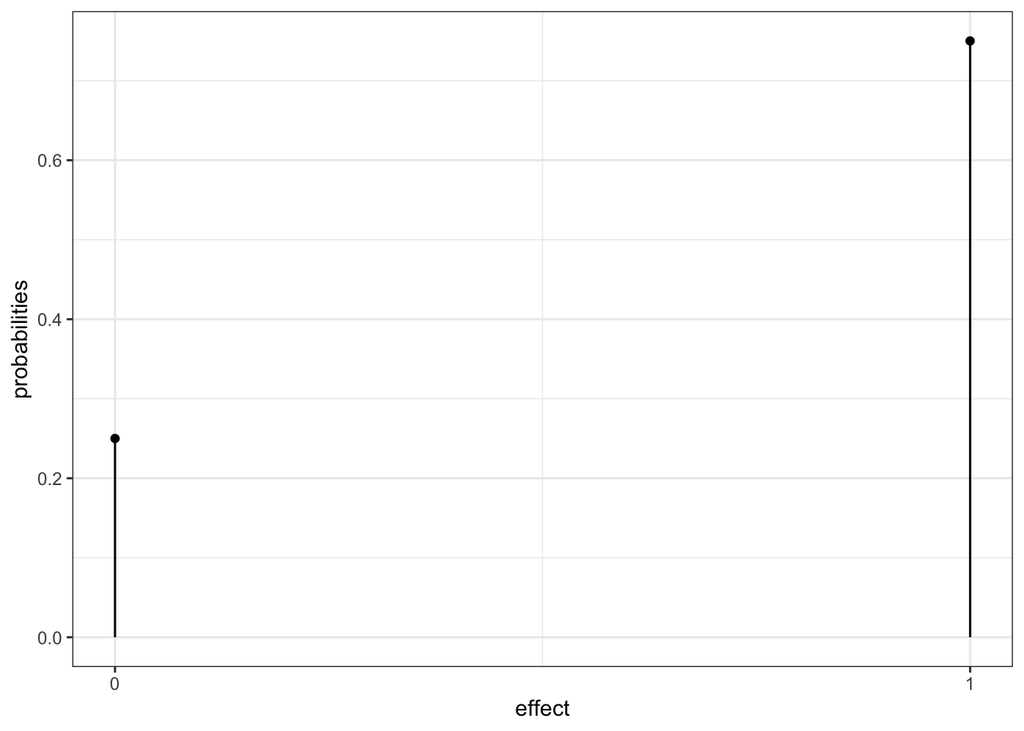

```r
p = 0.75 # Задаем истинную вероятность выздороветь
n_patients <- 20 # Количество добровольцев

effect <- c(1, 0) # Есть или нет эффект от терапии
probabilities <- c(p, 1-p)
   # Распределение в генеральной совокупности

df <- data.frame(effect, probabilities)

ggplot(df, aes(x=effect, y=probabilities)) +
  geom_point() +
  geom_segment( aes(x=effect, xend=effect, y=0, yend=probabilities)) +
  scale_x_continuous(breaks = effect) +
  theme_bw()
```

## Однократная оценка по выборке

```r
my_group_Hg_upd <- sample(effect, n_patients, replace = TRUE, prob = probabilities) # Результаты добровольцев

print(my_group_Hg_upd)
```

```
##  [1] 1 1 1 1 1 1 0 1 0 1 0 1 1 1 1 1 1 1 0 1
```

## Набираем статистику

```r
n_repeats <- 1000 # Количество повторений эксперимента

df_all_repeats <- data.frame(
  n_exp = rep(1:n_repeats, each = n_patients),
  ID = rep(1:n_patients, n_repeats)
) %>%
  group_by(n_exp) %>%
  mutate(Hg_upd = sample(effect, n_patients, replace = TRUE, prob = probabilities)) %>%
  ungroup()
```

## Ищем количество выздоровевших в каждом эксперименте

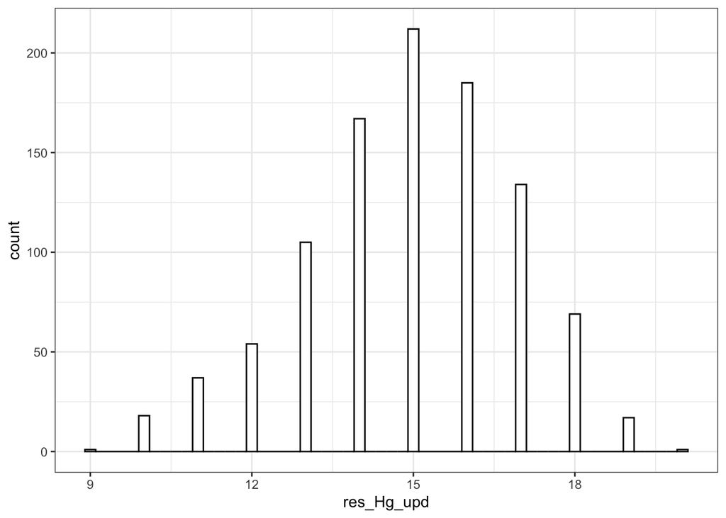

```r
df_sample_result <- df_all_repeats %>%
  group_by(n_exp) %>%
  dplyr::summarise(res_Hg_upd = sum(Hg_upd)) %>%
  ungroup()

ggplot(df_sample_result, aes(x = res_Hg_upd)) +
  geom_histogram(color = 'black', fill = 'white', binwidth = 0.2) +
  theme_bw()
```

## Ищем процент выздоровевших в каждом эксперименте

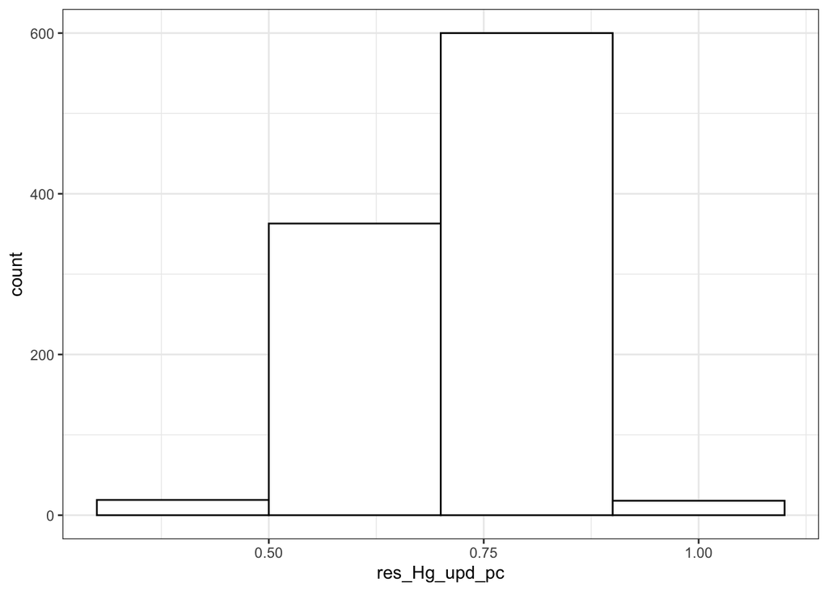

```r
df_sample_result_pc <- df_sample_result %>%
  mutate(res_Hg_upd_pc = res_Hg_upd / n_patients)

ggplot(df_sample_result_pc, aes(x = res_Hg_upd_pc)) +
  geom_histogram(color = 'black', fill = 'white', binwidth = 0.2) +
  theme_bw()
```

## Количественные и качественные итоги

```r
error <- sqrt( mean((df_sample_result_pc$res_Hg_upd_pc-p)^2) )

print(error)
```

```
## [1] 0.09733961
```

Для p = 0.05 и n_patients = 5 error = 0.09581232

Для p = 0.05 и n_patients = 20 error = 0.04964877

Для p = 0.05 и n_patients = 50 error = 0.03067246

Для p = 0.5 и n_patients = 5 error = 0.215963

Для p = 0.5 и n_patients = 20 error = 0.1113553

Для p = 0.5 и n_patients = 50 error = 0.07002857

Для p = 0.25 и n_patients = 5 error = 0.1885736

Для p = 0.25 и n_patients = 20 error = 0.09723682

Для p = 0.25 и n_patients = 50 error = 0.0589101

## Сделаем таблицу

```r
probabilities <- c(0.05, 0.05, 0.05, 0.5, 0.5, 0.5, 0.25, 0.25, 0.25)
n_patients <- c(5, 20, 50, 5, 20, 50, 5, 20, 50)
errors <- c(0.09581232, 0.04964877, 0.03067246, 0.215963, 0.1113553, 0.07002857, 0.1885736, 0.09723682, 0.0589101)

df_simulations <- data.frame(probability = probabilities, n_patients = n_patients, error = errors)

df_simulations <- df_simulations  %>%
  mutate(error_pc = error * 100 / probabilities)

df_simulations
```

```
##   probability n_patients      error  error_pc
## 1        0.05          5 0.09581232 191.62464
## 2        0.05         20 0.04964877  99.29754
## 3        0.05         50 0.03067246  61.34492
## 4        0.50          5 0.21596300  43.19260
## 5        0.50         20 0.11135530  22.27106
## 6        0.50         50 0.07002857  14.00571
## 7        0.25          5 0.18857360  75.42944
## 8        0.25         20 0.09723682  38.89473
## 9        0.25         50 0.05891010  23.56404
```

## Сделаем визуализацию

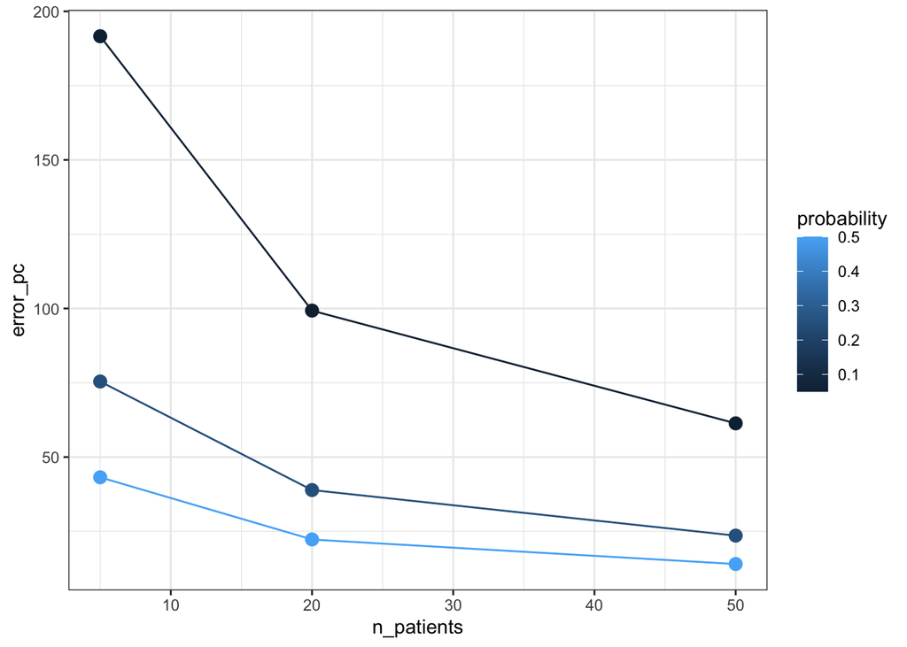

```r
ggplot(df_simulations, aes(x = n_patients, y = error_pc, color = probability, group = probability)) +
  geom_line() +
  geom_point(size = 3) +
  theme_bw()
```

Получается, ошибка уменьшается при увеличении выборки (неудивительно) и с приближением значений вероятностей исхода к равным значениям (к равномерному распределению вероятностей исхода). То есть чем ближе функция распределения средних к нормальному распределению, тем меньше ошибка оценки вероятности.